# Data Handling, Statistics & DoE

### for Materials Scientists

**Lecture 1** · 2 × 45 min

Course introduction · Working with data & collaboration · Part II: Data Handling & Materials Ontologies

*1KB570 · 5 credits · Second cycle*  
*Department of Chemistry – Ångström, Uppsala University*

## Today's Agenda

**2 x 45 min**, roughly in this order:

1. Why data, why now — the big picture
2. Course layout: lectures, live tutorials, laborations, project
3. Prerequisites, extra material & the course book
4. Using LLMs well in this course
5. Working with data in this course
6. Collaboration: Git & GitHub
7. *Break*
8. **Part II: Data Handling & Materials Ontologies**
9. Preparing for the two live-tutorial workshops
10. Wrap-up & what's next

## Course Layout: How This Course Runs

| Component | What it is |
| --- | --- |
| **Lectures** | Concept introductions, like this one — one per major Part |
| **Live tutorials** | 10 hands-on sessions across the book, worked live at the keyboard |
| **Laborations** | 3 lab exercises (next slide) |
| **Course project** | An independent analysis of your choosing, presented not written up |

**Examination**: a written exam, the mandatory laborations, and the course project together — not one single grade for the whole course.

Everything above is built around one Jupyter Book — **your course book**, covered in full a few slides from now.

## Three Laborations

| # | Topic | Status |
| --- | --- | --- |
| **1** | Part I refresher — make sure your Python environment works, ask questions if you feel rusty | *Optional* |
| **2** | Wine Quality: data curation → PCA → PLS or LDA | **Mandatory** |
| **3** | DoE Optimisation Contest — find a process optimum in as few experiments as possible, against a live "plant" server | **Mandatory** |

Laborations 2 and 3 are both **4-hour sessions with checkpoint questions instead of a written report** — you demonstrate understanding by answering directly, not by writing up a lab report afterwards.

Laboration 1 is not graded, but if Part I (Python basics) feels shaky, that session is exactly the place to fix it — with help in the room — before it becomes a problem in Laboration 2.

## The Course Project

Pick a **publicly available materials-science dataset**, apply what you've learned across the course, and **present your findings in a 10-minute talk** — that presentation, not a written report, is the graded deliverable. A reproducible Jupyter Notebook backs the talk, but you don't submit it as a stand-alone document.

- Choose your own dataset (suggestions provided) or one of five ready-made project topics
- At least four of: descriptive stats, a hypothesis test, a regression/PLS model, PCA/LDA, a DoE-style optimisation, or a method comparison
- Optional: compare a classical method against one from Part VI (AI/ML)

**Full details, suggested datasets, and grading criteria**: Part VII of the course book.

## Prerequisites & Extra Material

**Prerequisites**

- Basic Python — Part I of the book is a self-study refresher, not a formal requirement you're assumed to have passed elsewhere
- No prior statistics or DoE background assumed — this course builds both from the ground up

**Extra material**

- **Part VI: Intro to AI & Machine Learning** is explicitly *optional*, beyond the core syllabus — clustering, Gaussian processes, Bayesian optimisation, ensembles, neural networks
- Useful for the course project's optional ML-comparison step, and worth exploring if you want to go further than the graded material requires

## This Jupyter Book Is Your Textbook

**Everything in this course — theory, worked examples, live tutorials, labs, the project guide — lives in one place:**

`peterbmob.github.io/1kb570_2026`

- Every single notebook page has an **Open in Colab** button — click it, and you're editing and running that exact page's code in your browser, no install, no account needed
- This lecture itself is one of those notebooks — the live-runnable slides you're looking at right now
- Want it on your own computer instead? Clone the repository: `git clone https://github.com/peterbmob/1kb570_2026.git`

## The Book's Structure: Seven Parts

| Part | Topic | Key tools |
| --- | --- | --- |
| I | Prerequisites — Python for Data Analysis | numpy, pandas, matplotlib, plotly |
| **II** | **Data Handling & Materials Ontologies ← today** | json, pandas, owlready2, rdflib |
| III | Applied Statistics | scipy.stats, statsmodels |
| IV | Multivariate Analysis | scikit-learn, factor_analyzer |
| V | Design of Experiments | pyDOE3, scipy.optimize |
| VI | Intro to AI & Machine Learning (extra) | scikit-learn |
| VII | Course Project | everything above |

## Why Data, Why Now

- **Science is producing more data than any one person can manually curate**
  - Instruments, simulations, and high-throughput experiments now generate data faster than it can be read, let alone re-checked, by hand
  - The bottleneck is shifting from *"how do I get a measurement"* to *"how do I find, trust, and reuse the measurements that already exist"*
- **Research is becoming more collaborative and more interdisciplinary**
  - A single materials project now routinely spans synthesis chemists, computational scientists, and data/ML specialists — often across institutions and countries
  - That only works if data means the same thing to everyone touching it — exactly the problem Part II's FAIR principles and ontologies (EMMO) solve
- **Modern AI and machine learning are fundamentally data-hungry**
  - A model is only as good as the data it was trained and validated on
- **Reproducibility has become a serious concern across science**
  - Results that can't be reproduced — because data or methods were never properly documented — are a real, costly problem

## Materials Science Is Part of This Shift

- From single-sample, single-lab studies toward **shared, data-driven infrastructure**
  - High-throughput experimentation, autonomous/self-driving labs, digital twins
  - Large public materials databases now hold millions of entries — **NOMAD**, Materials Project, AFLOW, OQMD
- These infrastructures only work because of the ideas in **Part II, today**
  - FAIR metadata, shared ontologies (EMMO), structured queryable databases
- Funders increasingly **require** this — EU Horizon Europe and most national research councils now expect a data management plan and FAIR data as standard practice
- None of this works without people from different backgrounds agreeing on what a field even *means* — the interdisciplinary/collaboration point from the previous slide, made concrete

> Today's second workshop puts you inside a real example of this shift: querying **NOMAD**, a live, public, production-scale materials-data infrastructure, yourself.

## The Three Pillars of This Course

Everything in this book fits under three questions, in this order:

| Pillar | Question | Part |
| --- | --- | --- |
| **1. Handle** | Is your data structured and described well enough to trust and reuse? | **Part II** ← today |
| **2. Analyze** | Given data you already have, what can you honestly conclude from it? | Parts III–IV |
| **3. Generate** | If you need *more* or *better* data, how do you get the most out of every expensive experiment? | Part V (DoE) |

Handling data badly wastes the analysis; analysing badly-designed data wastes the experiment. **DoE (Part V) closes the loop** — it's literally the discipline of generating data efficiently in the first place, which is why it's the course's final methodological Part before the project.

## Using LLMs Well in This Course

**You are allowed to use LLMs (ChatGPT, Claude, Copilot, ...) in this course.** With every notebook now one click away in Colab, there's nothing stopping you from pasting code in and running it — so this needs saying plainly:

- **You are examined on understanding, not on producing working code.** The written exam tests whether *you* can choose the right test, read a p-value, design a factorial, interpret a loading plot — with no LLM in the room.
- **Using an LLM to skip that understanding now is a loan against the exam later.** Code that runs today because an LLM wrote it doesn't teach you anything the exam will ask you to reproduce.
- **Using an LLM to build understanding is genuinely useful** — and encouraged.

> The difference isn't *whether* you use one — it's *what you ask it for*.

## Good Prompt vs. Bad Prompt

| ❌ Fast-completion (avoid) | ✅ Hint-seeking (encouraged) |
| --- | --- |
| *"Write the code to run a two-sample t-test on this data"* | *"I think I need a two-sample t-test here — what should I check before trusting one?"* |
| *"Fix this error for me"* (paste, get code back, move on) | *"Explain what this error message means, in plain terms"* |
| *"What's the answer to Checkpoint 2b?"* | *"Here's my reasoning for Checkpoint 2b — does it hold together?"* |
| Copy → paste → run → hand in | Read the explanation → try it yourself → use the LLM to check your reasoning |

The left column gets you a working cell today and a blank page in the exam hall. The right column is slower right now and is exactly what actually prepares you for the written exam — treat an LLM like a very patient teaching assistant who won't just do the exercise for you.

# Working with Data in This Course

### Why almost every notebook you will see — today and for the rest of the course — starts from simulated data with a known right answer

## Why Generated (Simulated) Data?

Every case study in this course — ZnO grain size, NMC cathode capacity, LiFePO4 batches, TiO2 photocatalysis — starts from a **known true relationship plus random noise**. That is deliberate:

1. **You can check whether a method actually recovers the truth** — a t-test, a PCA, a factorial design — because you built the true answer in yourself. Real data never lets you do that.
2. **It's fully reproducible** — same seed, same numbers, same discussion, for every student, every time
3. **It's safe and fast** — no lab time, no reagent cost; try 10,000 experiments before running one real one
4. **It mirrors real practice** — this is exactly what a statistician calls a *Monte Carlo check*

## A Synthetic Dataset, Live

Simulating 100 charge-discharge cycles of a battery — exponential capacity fade plus measurement noise. **Run the cell below live.**

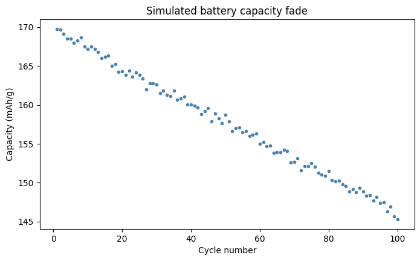

```
Cycle 1:   169.75 mAh/g
Cycle 100: 145.30 mAh/g
```

```python
import numpy as np
import matplotlib.pyplot as plt

rng = np.random.default_rng(7)          # <- try changing this seed and re-running!
cycle_numbers = np.arange(1, 101)
capacity_0 = 170.0     # mAh/g
fade_rate = 0.0015     # capacity loss per cycle

capacity = capacity_0 * np.exp(-fade_rate * cycle_numbers) + rng.normal(0, 0.5, 100)

plt.figure(figsize=(8, 4.5))
plt.plot(cycle_numbers, capacity, '.', color='steelblue')
plt.xlabel('Cycle number'); plt.ylabel('Capacity (mAh/g)')
plt.title('Simulated battery capacity fade')
plt.show()

print(f'Cycle 1:   {capacity[0]:.2f} mAh/g')
print(f'Cycle 100: {capacity[99]:.2f} mAh/g')
```

# Collaboration: Git & GitHub

### The same discipline as FAIR data principles (coming up next) — applied to code instead of data

## The Problem: `analysis_v2_final_REALLY.ipynb`

Renaming files by hand fails, and gets worse the longer a project runs:

- No record of **why** something changed
- No way to see exactly what changed between two versions without eyeballing both
- No safe way for two people to edit the same file at once without overwriting each other

**Version control (git) fixes all three at once** — every commit records exactly what changed, who, and why; the complete history is always available; two people's independent changes can usually be combined automatically.

## A Commit Is Just a Labelled Snapshot

A tiny in-memory stand-in for git's commit history — the same mental model as the real thing.

```python
import hashlib
from datetime import datetime, timedelta

class ToyRepo:
    '''A tiny, in-memory stand-in for git's commit history.'''
    def __init__(self):
        self.commits = []          # chain of snapshots, oldest first
        self.working_files = {}    # current file contents

    def _commit_id(self, message, timestamp):
        raw = f'{message}{timestamp}{len(self.commits)}'.encode()
        return hashlib.sha1(raw).hexdigest()[:7]

    def commit(self, message, author='you'):
        parent = self.commits[-1]['id'] if self.commits else None
        timestamp = datetime.now() + timedelta(seconds=len(self.commits))
        snapshot = {'id': self._commit_id(message, timestamp), 'parent': parent,
                    'message': message, 'author': author, 'timestamp': timestamp,
                    'files': dict(self.working_files)}
        self.commits.append(snapshot)
        return snapshot['id']

    def log(self):
        for c in reversed(self.commits):
            print(f"{c['id']}  {c['timestamp']:%Y-%m-%d %H:%M:%S}  {c['author']:<8} {c['message']}")


repo = ToyRepo()
repo.working_files['analysis.py'] = "print('load data')"
repo.commit('Initial analysis script')

repo.working_files['analysis.py'] += "\nprint('clean data')"
repo.commit('Add data cleaning step')

repo.log()
```

```
65b3508  2026-08-27 12:58:43  you      Add data cleaning step
cf61b68  2026-08-27 12:58:42  you      Initial analysis script
```

Nothing is ever overwritten — an earlier snapshot is always reachable through the chain. Real commands: `git init` · `git add` · `git commit -m "message"` · `git log`.

## Branches: Try an Idea Without Breaking What Works

Keep a stable line of commits untouched (`main`) while trying something risky on a separate line.

```python
class BranchingRepo(ToyRepo):
    def __init__(self):
        super().__init__()
        self.branches = {'main': None}   # branch name -> commit id it points to
        self.current_branch = 'main'

    def commit(self, message, author='you'):
        commit_id = super().commit(message, author)
        self.branches[self.current_branch] = commit_id
        return commit_id

    def branch(self, name):
        self.branches[name] = self.branches[self.current_branch]

    def checkout(self, name):
        self.current_branch = name

    def status(self):
        print(f"On branch '{self.current_branch}'")
        for name, cid in self.branches.items():
            marker = ' <-- you are here' if name == self.current_branch else ''
            print(f"  {name}: {cid}{marker}")


brepo = BranchingRepo()
brepo.working_files['model.py'] = "model = 'MLR'"
brepo.commit('Baseline: linear regression model')

brepo.branch('try-random-forest')     # fork off from the current commit
brepo.checkout('try-random-forest')
brepo.working_files['model.py'] = "model = 'RandomForest'"
brepo.commit('Experiment: swap in a Random Forest')

brepo.status()
```

```
On branch 'try-random-forest'
  main: a561cfa
  try-random-forest: 2324ca4 <-- you are here
```

`main` still points at the safe baseline commit — the experiment cannot break it, no matter how badly it goes. Same discipline as testing a risky package upgrade in a throwaway conda environment first (Notebook 6).

## GitHub: Remotes and Working With Others

**The vocabulary**

- `clone` — download a full copy of a repository, history and all
- `push` — send your new local commits up to GitHub
- `pull` — download and merge commits someone else pushed

**Two collaboration shapes**

- **Direct collaborator**: added to a repo, branch → push → open a pull request for review
- **Fork**: no write access — make your own copy, change it, PR back to the original
- **Merge conflict**: two branches changed the same lines differently — git stops and asks you to decide by hand:

```
<<<<<<< HEAD
model = 'RandomForest'
=======
model = 'GradientBoosting'
>>>>>>> try-random-forest
```

## Two Habits Worth Adopting From Day One

**`.gitignore`** — a plain-text list of patterns git should never track: build artefacts, large data files, anything that regenerates automatically. Large raw data files belong in a proper database (coming up), not committed directly — git keeps *every* version of every tracked file forever.

**Notebooks in git** — `.ipynb` files store cell *outputs* alongside the code, so re-running and re-saving changes the file even when no code changed. Fix: clear outputs before committing, or use `nbstripout` to do it automatically.

*Worth setting up before your course-project notebook's history turns into hundreds of "re-ran cell 47" commits.*

## Break

### 5–10 minutes

Coming up after the break: **Part II — Data Handling & Materials Ontologies**, directly preparing both upcoming live-tutorial workshops.

# Part II — Data Handling & Materials Ontologies

A composition might live in a colleague's spreadsheet, a synthesis temperature in a lab notebook, an XRD pattern in an instrument's proprietary format — each using slightly different names for the same thing.

### This part is about closing that gap.

## Why This Part Exists

| Problem in the lab | Concept | Notebook |
| --- | --- | --- |
| "I don't remember what column T2 meant" | **Metadata** | 1 |
| "Is 'tensile strength' the same as 'ultimate tensile stress'?" | **Ontology (EMMO)** | 2 |
| "I need my group's data queryable, not just files" | **Database** | 3 |
| "Where do I put data so others can find it?" | **Repository (NOMAD)** | 4 |
| "How do I apply this to MY dataset?" | **Schema design** | 5 |

## Two Live Workshops, Directly Ahead

**Live Tutorial 1 — SQL & NoSQL in Practice**

- Entirely local — no network, no account needed
- A realistic lab-scale investigation using Notebook 3's concepts

**Live Tutorial 2 — The Real NOMAD API**

- Connects to the real, public NOMAD repository
- No registration needed for the reading/plotting done there

*Everything from here on is preparation for both.*

## Data Without Metadata Is (Almost) Useless

`182, 195, 188, 201, 179, 193`

What is this? Hardness values? In what units — Vickers, Brinell, Rockwell? Which sample? Which instrument? Measured when, by whom?

### A bare number is scientifically worthless without its context

**Metadata** = data about data — exactly the context a lab notebook records almost unconsciously, and exactly what gets lost when data moves into a bare spreadsheet or plot.

## The FAIR Principles

|  | Principle | The plain-language question |
| --- | --- | --- |
| **F** | Findable | Can a person or machine locate this dataset at all? |
| **A** | Accessible | Can it actually be fetched — even under conditions? |
| **I** | Interoperable | Can it combine with other data/tools with no manual translation? |
| **R** | Reusable | Is there enough context to reuse it correctly? |

**FAIR is a checklist, not a synonym for "open."** Data can be FAIR and still access-controlled or paywalled.

## Metadata in Python: Dictionaries and JSON

A dictionary is the natural structure for metadata — it's inherently nested. JSON is the standard interchange format (human-readable, near-lossless, what NOMAD uses under the hood).

```python
import json

cathode_record = {
    'identifier': 'urn:uuid:1234',
    'title': 'LiFePO4 cathode, solid-state synthesis batch 07',
    'licence': 'CC-BY-4.0',
    'creator': 'A. Lindqvist',
    'created': '2025-01-15',
    'method': 'solid-state reaction, 2-step calcination',
    'data': {'temperature_C': 750, 'time_h': 6, 'capacity_mAh_g': 161.4},
}

def fair_check(record):
    '''Which required FAIR-relevant fields, if any, are missing?'''
    required = ['identifier', 'title', 'licence', 'creator', 'created', 'method']
    missing = [k for k in required if k not in record]
    return not missing, missing

ok, missing = fair_check(cathode_record)
print('FAIR check passed:', ok)

# JSON round-trip: save, then load back
record_json = json.dumps(cathode_record, indent=2)
reloaded = json.loads(record_json)
print('Round-trip identical:', reloaded == cathode_record)
print(record_json)
```

```
FAIR check passed: True
Round-trip identical: True
{
  "identifier": "urn:uuid:1234",
  "title": "LiFePO4 cathode, solid-state synthesis batch 07",
  "licence": "CC-BY-4.0",
  "creator": "A. Lindqvist",
  "created": "2025-01-15",
  "method": "solid-state reaction, 2-step calcination",
  "data": {
    "temperature_C": 750,
    "time_h": 6,
    "capacity_mAh_g": 161.4
  }
}
```

*This exact record reappears across the rest of today — rebuilt as an ontology individual, SQL rows, MongoDB documents, and a NOMAD-style archive.*

## The Problem: Words Are Not Reliable Identifiers

**Synonymy** — same concept, different words

- "yield strength" / "0.2% proof stress" / σy — a naive string filter misses the aliases

**Homonymy** — same word, different concepts

- "annealing" in metallurgy vs. molecular biology
- "conductivity" without a qualifier — electrical, or thermal?

A column header is just a string — it cannot disambiguate on its own.

## Controlled Vocabulary → Taxonomy → Ontology

| Level | What it provides | Example | Limitation |
| --- | --- | --- | --- |
| Controlled vocabulary | A flat, fixed term list | `{as-cast, annealed, quenched}` | No structure |
| Taxonomy | Vocabulary + an is-a hierarchy | Linnaean classification | One relation type only |
| **Ontology** | Taxonomy + relations, properties, formal logic | **EMMO** | Real upfront modelling effort |

## EMMO — The European Materials & Modelling Ontology

A **foundational, top-level ontology** for physical science and engineering.

- Developed/maintained by the European Materials Modelling Council (EMMC)
- Open, versioned, at a persistent ID (`w3id.org/emmo`), CC-BY-4.0
- Every concept ultimately derives from one root class: `Item`
- Domain ontologies build on top of it — e.g. **BattINFO** for FAIR battery data
- NOMAD increasingly annotates its own schemas with EMMO concepts

## The Key Insight: A Measurement Is Not the Property

**A material — Crystal** `Crystal → CrystallineMaterial → Material → OrdinaryMatter → PhysicalObject → … → Item`

**A quantity — SpecificHeatCapacity** `SpecificHeatCapacity → Sign → SemioticEntity → Semiotics → … → Item`

*(Real EMMO ancestor chains, walked live via SPARQL against the actual ontology.)*

"188 HV" is a **Sign** representing a real hardness, not the hardness itself.

## Try It: A Toy Ontology, Live

Building the same idea in miniature with `owlready2` — the same building blocks EMMO itself is built from.

```python
from owlready2 import get_ontology, Thing, ObjectProperty

onto = get_ontology("http://example.org/toy_emmo.owl")

with onto:
    class Item(Thing): pass
    class PhysicalEntity(Item): pass
    class Quantity(Item): pass
    class MaterialObject(PhysicalEntity): pass
    class CathodeMaterial(MaterialObject): pass
    class ThermodynamicTemperature(Quantity): pass

    class hasQuantitativeProperty(ObjectProperty):
        domain = [MaterialObject]
        range = [Quantity]

batch_07 = CathodeMaterial("LiFePO4_batch_07")
T_synthesis = ThermodynamicTemperature("T_synthesis_batch_07")
batch_07.hasQuantitativeProperty.append(T_synthesis)

print("Is batch_07 a MaterialObject?", isinstance(batch_07, MaterialObject))
print("Ancestors of CathodeMaterial:", [c.name for c in CathodeMaterial.ancestors()])
```

```
Is batch_07 a MaterialObject? True
Ancestors of CathodeMaterial: ['MaterialObject', 'Item', 'Thing', 'CathodeMaterial', 'PhysicalEntity']
```

## Beyond the Hierarchy: What Makes an Ontology *Do* Things

A class hierarchy alone is just an organised list. The full Notebook 2 goes further, with four live demonstrations of what that structure actually buys you:

- **See it as a graph** — the same toy ontology drawn as an actual knowledge graph (`networkx`): classes and individuals as nodes, relations as labelled edges
- **Reasoning** — a real OWL-RL reasoner (`owlrl`) derives a fact that was *never explicitly written down*, purely from the axioms already in place
- **Closing the loop on synonymy** — two records using different labels ("yield strength" vs. "0.2% proof stress") are still found together by one class-based query, exactly the Section 2.1 problem, now solved
- **Catching a wrong unit** — the ontology flags a hardness value mistakenly recorded in a pressure unit, something a bare CSV column never would

*This is the concrete answer to "why not just use a spreadsheet with good column names?"*

## Why a Database at All?

A dict / JSON file (previous section) works for a handful of records. It breaks down once you have:

- Thousands of records
- Multiple people writing at the same time
- Cross-record questions — filter, join, aggregate

Notebooks 1–2 solved a **meaning** problem. This solves an **infrastructure** problem.

## Two Data Models: Rows vs. Documents

|  | Relational (SQL) | Document (NoSQL) |
| --- | --- | --- |
| Shape | Fixed-column tables of rows | Nested, JSON-like documents |
| Schema | Enforced upfront | Flexible, per-document |
| Relationships | Foreign keys + JOIN | Usually embedded |
| Query language | SQL | Method-call API |
| Systems | PostgreSQL, MySQL, SQLite | MongoDB, CouchDB |
| Good fit for | Strictly tabular, strict integrity | Heterogeneous, nested data |

## SQL, Live

A small relational schema — `samples` and `results`, linked by a foreign key. Watch what happens when a `NOT NULL` constraint is violated.

```python
import sqlite3
import pandas as pd

conn = sqlite3.connect(':memory:')
conn.execute('''CREATE TABLE samples (
    sample_id TEXT PRIMARY KEY, material TEXT, method TEXT NOT NULL
)''')
conn.execute('''CREATE TABLE results (
    sample_id TEXT PRIMARY KEY, capacity_mAh_g REAL,
    FOREIGN KEY(sample_id) REFERENCES samples(sample_id)
)''')

samples = [('batch_05', 'LiFePO4', 'solid-state'), ('batch_06', 'LiFePO4', 'sol-gel'),
           ('batch_07', 'LiFePO4', 'solid-state')]
conn.executemany('INSERT INTO samples VALUES (?,?,?)', samples)
results = [('batch_05', 158.2), ('batch_06', 163.9), ('batch_07', 161.4)]
conn.executemany('INSERT INTO results VALUES (?,?)', results)
conn.commit()

df = pd.read_sql_query('''
    SELECT s.sample_id, s.method, r.capacity_mAh_g
    FROM samples s JOIN results r ON s.sample_id = r.sample_id
''', conn)
print(df)

# Schema enforcement, live: try to insert a sample with no method
try:
    conn.execute("INSERT INTO samples VALUES ('batch_08', 'LiFePO4', NULL)")
except sqlite3.IntegrityError as e:
    print('\nRejected:', e)
```

```
  sample_id       method  capacity_mAh_g
0  batch_05  solid-state           158.2
1  batch_06      sol-gel           163.9
2  batch_07  solid-state           161.4

Rejected: NOT NULL constraint failed: samples.method
```

## Document Store, Live

```python
import mongomock

client = mongomock.MongoClient()
db = client.cathode_db
db.batches.insert_many([
    {'sample_id': 'batch_05', 'method': 'solid-state',
     'steps': [{'name': 'mixing'}, {'name': 'calcination'}],
     'results': {'capacity_mAh_g': 158.2}},
    {'sample_id': 'batch_06', 'method': 'sol-gel',
     'steps': [{'name': 'gelation'}],
     'results': {'capacity_mAh_g': 163.9}},
])
# A document missing 'results' entirely -- accepted without error, no migration needed
db.batches.insert_one({'sample_id': 'batch_10', 'method': 'solid-state', 'steps': []})

for doc in db.batches.find({'method': 'sol-gel'}):
    print(doc['sample_id'], doc['results'])

print("\nbatch_10 has a 'results' field?", 'results' in db.batches.find_one({'sample_id': 'batch_10'}))
```

```
batch_06 {'capacity_mAh_g': 163.9}

batch_10 has a 'results' field? False
```

### "Document databases trade upfront enforcement for upfront flexibility — which one you want depends on how settled your data's shape already is."

## Choosing a Model

|  | Relational (SQL) | Document (NoSQL) | Domain repository (NOMAD) |
| --- | --- | --- | --- |
| Schema enforcement | Strict, built-in | Flexible / opt-in | Strict, validated |
| Best for | Fixed-shape registries | Heterogeneous exports | FAIR, ontology-aware data |
| You set up yourself | Yes | Yes | No — used as infrastructure |
| Ontology-aware | No | No | Yes — EMMO concept tags |

## ▶ Coming Up: Live Tutorial 1 — SQL & NoSQL in Practice

- Grow the dataset: 5 batches → 45 batches across 3 calcination furnaces
- Investigate **"the furnace mystery"** — is Furnace-C really under-performing?
- Answer the same question independently in SQL and MongoDB, then cross-check
- See schema enforcement differences live
- Optional: indexing and query performance at real scale (200,000 rows)

*Entirely local. No accounts, no installs, no internet needed.*

## What Is NOMAD?

An **open-source, FAIR data infrastructure** for materials science (`nomad-lab.eu`).

- Developed by **FAIRmat** — part of Germany's National Research Data Infrastructure (NFDI)
- Started for computational/DFT/simulation data
- Has grown **Electronic Lab Notebook (ELN)** support for experimental data

**NOMAD Oasis**: the same software, run as your own private instance — for unpublished results or embargoed data, speaking the same data model as public NOMAD.

## Anatomy of a NOMAD Entry

| Layer | What it is | Analogy from earlier today |
| --- | --- | --- |
| Raw data | The original files, untouched | The instrument's raw export |
| Archive | Parsed into NOMAD's structured schema | The FAIR `cathode_record` dict — now machine-validated |
| Metadata | Searchable summary fields | The F / A / R fields from `fair_check` |

## Where EMMO Fits In, Live

NOMAD schemas attach an ontology **concept IRI** to individual quantities, so differently-named fields in different labs can still be recognised as the same concept.

```python
nomad_style_entry = {
    'metadata': {'upload_id': 'upload_2025_01_cathodes', 'entry_id': 'entry_LiFePO4_batch07',
                 'authors': ['A. Lindqvist'], 'licence': 'CC-BY-4.0'},
    'archive': {'data': {
        'm_def': 'CathodeSynthesisEntry',
        'synthesis': {'method': 'solid-state reaction'},
        'results': {'capacity_mAh_g': 161.4,
                    'quantity_kind_iri': 'emmo:ElectricCharge'},   # <- the EMMO tag
    }},
}

def validate_entry(entry, schema):
    '''A minimal structural validator -- same spirit as fair_check, checking
    structure instead of FAIR-ness.'''
    for key, expected_type in schema.items():
        node = entry
        for part in key.split('.'):
            if part not in node:
                return False, f'missing {key}'
            node = node[part]
        if not isinstance(node, expected_type):
            return False, f'{key} has wrong type'
    return True, None

schema = {
    'archive.data.synthesis.method': str,
    'archive.data.results.capacity_mAh_g': (int, float),
}
print(validate_entry(nomad_style_entry, schema))
```

```
(True, None)
```

## ▶ Coming Up: Live Tutorial 2 — The Real NOMAD API

- Query the real, public, live NOMAD repository over the internet — 759,000+ iron-containing entries
- A search-semantics gotcha: "all" these elements vs. "exactly" these elements
- Paginate through hundreds of results with a cursor, not page numbers
- Two-step pattern: search the index (fast) → fetch full archives (selective)
- Unit discipline: NOMAD stores SI units — convert J → eV before anything is meaningful
- Case study: computed (DFT) band gaps for ZnO systematically under-estimate the real value
- Optional: a personal access token — what changes once you're authenticated

*No account needed for ~90% of the session — stable internet required.*

## Notebook 5 — Putting It All Together

**Design schema** → **Builder function** → **Generate** (12 samples) → **Validate** (every record) → **Export** (CSV + JSON archive) → **Round-trip check** → **FAIR-check** (dataset level)

A 12-sample tool-steel hardness study (temperature × time × quench medium) — the exact shape of deliverable you'll produce for the real course project.

*Honest gap: hardness has no concept in core EMMO — the record uses a clearly-marked local placeholder (`local:VickersHardness`) instead of inventing a fake one.*

## This Is Your Course Project, in Miniature

- A schema that separates what you controlled from what you measured
- A validated, EMMO-tagged record for every sample — not just some
- Both a clean analysis-ready table **and** a full metadata archive

**Forward link**: the exported CSV is exactly the file format Part III's statistics notebooks expect — group means, ANOVA across temperature and quench medium.

## Before the Workshops: Checklist

**A working Python environment**

- Easiest: click **Open in Colab** on any book page — zero install, runs in your browser
- Or local (Anaconda/Miniconda) + `requirements.txt`, if you prefer your own machine

**Live Tutorial 1 (SQL & NoSQL)**

- Nothing extra — entirely local, no accounts or servers

**Live Tutorial 2 (NOMAD API)**

- Stable internet access
- Optional: a free NOMAD account + Personal Access Token

## Key Takeaways From Today

1. Simulated data with a known true answer lets us check whether a method actually works
2. Git and GitHub make analysis reproducible and collaborative
3. FAIR + EMMO ensure data means the same thing to different people and software
4. SQL vs. NoSQL is a genuine trade-off — enforcement vs. flexibility
5. NOMAD is a concrete, worked FAIR repository — two workshops now put this in your hands

## Coming Up

**Next:** Live Tutorial 1 — SQL & NoSQL in Practice `chapters/02_data_handling/06_live_tutorial_1_sql_nosql.ipynb`

**Then:** Live Tutorial 2 — The Real NOMAD API `chapters/02_data_handling/07_nomad_api_live_tutorial.ipynb`

**Later:** Part III — Applied Statistics

## Questions?

**1KB570 — Data Handling, Statistics & Design of Experiments for Materials Scientists**

Department of Chemistry – Ångström, Uppsala University